# Complex data - Homework 3

Błażej Wiórek

5/12/2020

## Dataset

Sixty overweight male subjects were randomly assigned to one oftwo weight loss programs. Both programs required subjects tofollow a strict diet regimen and a daily exercise routine. Inaddition, subjects in program 1 received daily encouragement froma representative from the study, while subjects in program 2received no such encouragement. Weight (in pounds) was measuredat baseline (month 0) and at 3, 6, and 9 months thereafter.

Mean within groups:

```
##          1        2
## 0 241.6088 244.9500
## 3 219.2059 237.0038
## 6 193.7706 227.1192
## 9 169.0441 218.0346
```

Standard deviation within groups:

```
##          1        2
## 0 23.01513 21.72067
## 3 21.19745 20.40583
## 6 21.92547 24.62901
## 9 21.99597 20.59980
```

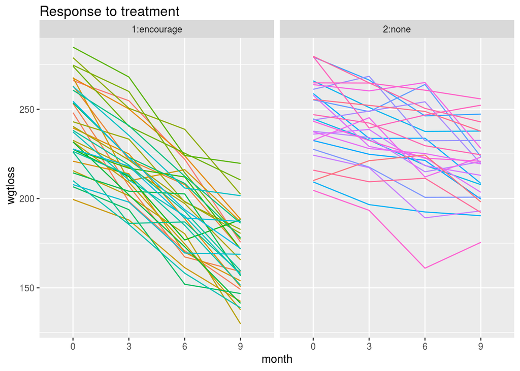

## Compare covariance structures

### Compound Symmetry vs. Unstructured

```
##               LogLik Cov. params
## unconstr 1900.876689          10
## constr   1905.823257           2
## diff        4.946568           8
```

```
## [1] "LRT p-val:  0.76327"
```

LRT yields $G^2=4.946568$ with 8 df (p=0.76327), so we accept the null hypothesis at $\alpha=0.05$ and conclude that the assumption of compound symmetry covariance structure is appropriate for the data.

### Autoregressive vs. Unstructured

```
##              LogLik Cov. params
## unconstr 1900.87669          10
## constr   1931.24684           2
## diff       30.37015           8
```

```
## [1] "LRT p-val:  0.00018"
```

LRT yields $G^2=30.37015$ with 8 df (p=0.00018), so we reject the null hypothesis at $\alpha=0.05$ and conclude that the assumption of autoregressive covariance structure is not sufficient when compared to unstructured.

### Compound Symmetry vs. Autoregressive

Log-Likelihood comparison:

```
## [1] "Compound symmetry:  1905.82325730877"
```

```
## [1] "Autoregressive:  1931.24683700434"
```

### Summing up with ANOVA

```
##                Model df      AIC      BIC    logLik   Test  L.Ratio p-value
## wtloss.un.cat      1 18 1936.877 1998.918 -950.4383
## wtloss.ar1.cat     2 10 1951.247 1985.714 -965.6234 1 vs 2 30.37015   2e-04
```

```
## [1] ""
```

```
##               Model df      AIC      BIC    logLik   Test  L.Ratio p-value
## wtloss.un.cat     1 18 1936.877 1998.918 -950.4383
## wtloss.cs.cat     2 10 1925.823 1960.291 -952.9116 1 vs 2 4.946568  0.7633
```

```
## [1] ""
```

```
##                Model df      AIC      BIC    logLik
## wtloss.ar1.cat     1 10 1951.247 1985.714 -965.6234
## wtloss.cs.cat      2 10 1925.823 1960.291 -952.9116
```

Thus, we will use a compound symmetry covariance structure for the remainder of the lab. The problem with these test is that they are based on REML instead of ML which may rise concerns in terms of their correctness.

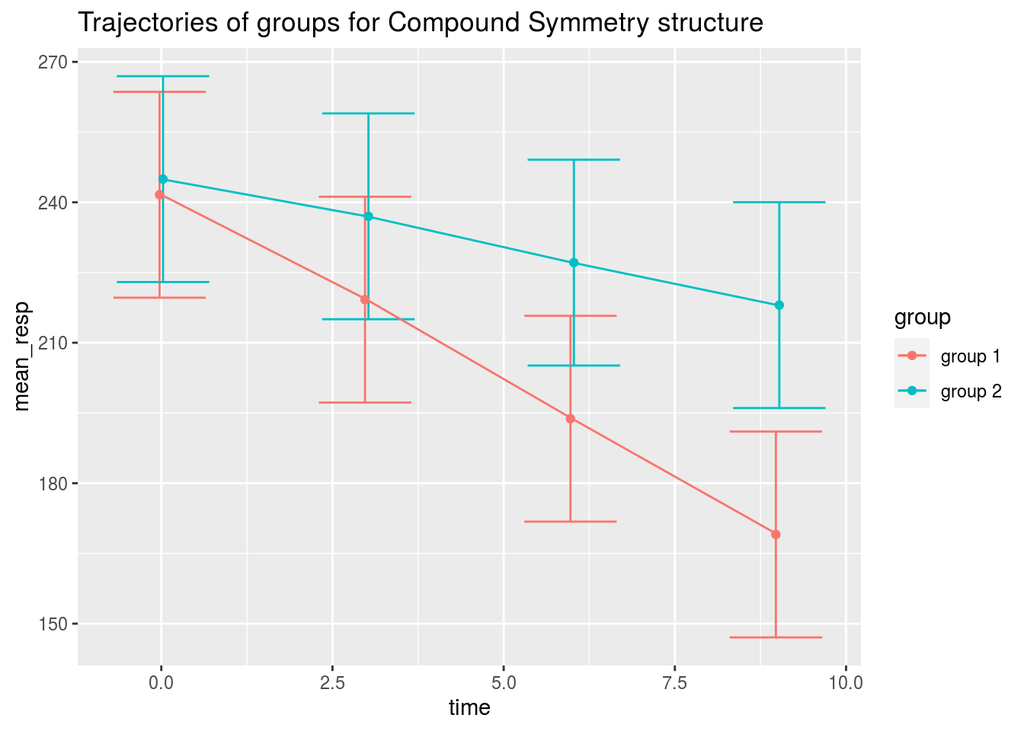

## AUC (minus baseline)

Mean weight levels at baseline, month 3, month 6, month 9

```
##              baseline       m3       m6       m9
## encourage    241.6088 219.2059 193.7706 169.0441
## no_encourage 244.9500 237.0038 227.1192 218.0346
```

In order to obtain mean AUC it’s sufficient to take a dot product of contrast L with rows of mean weight data frame.

```
##                    AUC
## encourage    -319.5706
## no_encourage -117.7038
```

Wald statistic is given by $W^2 = (L\hat{\beta})^T(L\hat{Cov}(\hat{\beta})L^T)^{-1}(L\hat{\beta}) \sim \chi^2_1$ under $H_0$, thus we have:

```
## [1] "Value of Wald statistic:  759.3707 , p-value:  3.680331856534e-167"
```

The conclusion is that we reject the null hypothesis of equal AUC’s.

## Parametric curves

### Quadratic Time Trend

```
## Generalized least squares fit by maximum likelihood
##   Model: wgtloss ~ month * prog.fac + I(month^2) * prog.fac
##   Data: wtloss.uni
##      AIC      BIC  logLik
##   1951.7 1979.545 -967.85
##
## Correlation Structure: Compound symmetry
##  Formula: ~1 | id
##  Parameter estimate(s):
##       Rho
## 0.8051072
##
## Coefficients:
##                               Value Std.Error  t-value p-value
## (Intercept)               241.79588  3.736159 64.71778  0.0000
## month                      -7.52343  0.864791 -8.69971  0.0000
## prog.fac2:none              3.29104  5.675632  0.57985  0.5626
## I(month^2)                 -0.06454  0.092082 -0.70092  0.4840
## month:prog.fac2:none        4.78702  1.313712  3.64389  0.0003
## prog.fac2:none:I(month^2)   0.03292  0.139883  0.23533  0.8142
##
##  Correlation:
##                           (Intr) month  prg.2: I(m^2) mn:.2:
## month                     -0.298
## prog.fac2:none            -0.658  0.196
## I(month^2)                 0.222 -0.958 -0.146
## month:prog.fac2:none       0.196 -0.658 -0.298  0.631
## prog.fac2:none:I(month^2) -0.146  0.631  0.222 -0.658 -0.958
##
## Standardized residuals:
##         Min          Q1         Med          Q3         Max
## -3.07768425 -0.71211768 -0.05393069  0.78189768  2.35199939
##
## Residual standard error: 21.6169
## Degrees of freedom: 240 total; 234 residual
```

Comparison of quadratic model (continuous time) vs. categorical time with Compound Symmetry structure.

```
##                 LogLik N of params
## saturated 1935.3313128          10
## reduced   1935.7000029           8
## diff         0.3686901           2
```

```
## [1] "LRT p-val:  0.83165"
```

LRT yields $G2=0.3686901$ (p=0.83165), so we fail to reject the null hypothesis at $\alpha=0.05$ and conclude that the model with Month as a quadratic effect seems to describe the data adequately

### Linear Time Trend

```
## Generalized least squares fit by maximum likelihood
##   Model: wgtloss ~ month * prog.fac
##   Data: wtloss.uni
##        AIC      BIC    logLik
##   1948.295 1969.179 -968.1477
##
## Correlation Structure: Compound symmetry
##  Formula: ~1 | id
##  Parameter estimate(s):
##       Rho
## 0.8045562
##
## Coefficients:
##                          Value Std.Error   t-value p-value
## (Intercept)          242.37676  3.628175  66.80405  0.0000
## month                 -8.10431  0.246441 -32.88537  0.0000
## prog.fac2:none         2.99477  5.511593   0.54336  0.5874
## month:prog.fac2:none   5.08329  0.374371  13.57820  0.0000
##
##  Correlation:
##                      (Intr) month  prg.2:
## month                -0.306
## prog.fac2:none       -0.658  0.201
## month:prog.fac2:none  0.201 -0.658 -0.306
##
## Standardized residuals:
##         Min          Q1         Med          Q3         Max
## -3.06377612 -0.70499619 -0.03751759  0.78186485  2.32456489
##
## Residual standard error: 21.62214
## Degrees of freedom: 240 total; 236 residual
```

```
##                 LogLik N of params
## saturated 1935.7000029           8
## reduced   1936.2954090           6
## diff         0.5954061           2
```

```
## [1] "LRT p-val:  0.74252"
```

LRT yields $G2=0.5954061$ ($p=0.74252$), so we don’t reject the null hypothesis at $\alpha=0.05$ and conclude that the model with Month as a linear effect fits the data better than the model with Month as a quadratic effect (based on AIC value).

Since the p-value for month*program is $\approx 0$, we reject the null hypothesis and conclude that there is a significant interaction between month and program. Thus, our final model is the linear model with interaction.

**What can you conclude about the two weight programs in terms of their effectiveness?**

Proposed model can be written as:
$$\mathbb{E}(Y_{ij}) = \beta_1 + \beta_2month_{ij} + \beta_3prog_{ij} + \beta_4 month_{ij} * prog_{ij}$$
Which leads to:
$$\mathbb{E}(Y_{ij}) = \beta_1 + \beta_3prog_{ij} + (\beta_2 + \beta_4*prog_{ij})*month_{ij}$$
Because $\beta_4 > 0$ we can conclude that the slope is steeper for weight program with encourage and it’s more effective, because on average it leads to faster weight loss.

### Interpreting quadratic trends:

```
## Generalized least squares fit by maximum likelihood
##   Model: wgtloss ~ prog.fac + month + I(month^2)
##   Data: wtloss.uni
##        AIC     BIC    logLik
##   2076.506 2097.39 -1032.253
##
## Correlation Structure: Compound symmetry
##  Formula: ~1 | id
##  Parameter estimate(s):
##       Rho
## 0.6542068
##
## Coefficients:
##                    Value Std.Error  t-value p-value
## (Intercept)    232.01185  3.760834 61.69160   0.000
## prog.fac2:none  25.86957  5.247814  4.92959   0.000
## month           -5.44906  0.927076 -5.87768   0.000
## I(month^2)      -0.05028  0.098715 -0.50933   0.611
##
##  Correlation:
##                (Intr) prg.2: month
## prog.fac2:none -0.605
## month          -0.317  0.000
## I(month^2)      0.236  0.000 -0.958
##
## Standardized residuals:
##         Min          Q1         Med          Q3         Max
## -2.68753310 -0.70290501 -0.02486406  0.70326142  2.27868518
##
## Residual standard error: 23.20979
## Degrees of freedom: 240 total; 236 residual
```

The model can be written as:
$$\mathbb{E}(Y_{ij}) = \beta_1 + \beta_2 time_{ij} + \beta_3 time^2_{ij} + \beta_4group_{ij}$$

Rate of change in program 1 is $\beta_2 + 2\beta_3 time_{ij}$.

[output not shown]

Thus, the mean response for Program 1 decreases over time.

**What about Program 2?**

Since rate of change doesn’t depend on $\beta_4$ it is the same for program 2. Expected response is different.